# Bayesian spatial autoregression in “nimble”

Sudipto Banerjee

2023-10-17

0. The root directory for this project has 3 subfolders: “data”, “src” and “test”. The source Rmd file is in the “test” directory. The “data” directory contains the data sets for this linear regression example. The “src” directory contains an R program called “data_prep_areal.R” to prepare the data into nimble format.
1. Remove all objects from R workspace—good programming practice and can help debug your code better.

```r
rm(list = ls())
```

2. Prepare the data by running the “data_prep_areal.R” file in the “src” directory. When preparing the data, it is important to note that “nimble” expects the dependent random variable(s) being modeled to be stored as a separate object from the covariates and other fixed variables. So we create “nimbleData” to store the “Y” and “nimbleConstants” to store the fixed matrix of regressors “X” and other constants.

```r
source("../src/data_prep_areal.R")
```

[output not shown]

```
## To access larger datasets in this package, install the spDataLarge
## package with: `install.packages('spDataLarge',
## repos='https://nowosad.github.io/drat/', type='source')`
```

```
## Spherical geometry (s2) switched off
```

```
## although coordinates are longitude/latitude, st_intersects assumes that they
## are planar
```

3. Load “nimble” and “coda” packages

```r
library(nimble)
library(coda)
```

4. The code in “data_prep_areal.R” creates “nimbleData” (Y), “nimbleConst” (X) and “nimbleInits”. For “nimbleInits”, apart from the different model parameters, we also initialize a variable “yFit” that represents the (posterior predictive) model-fitted distribution for each data point, i.e., “yFit[i] ~ dnorm(mu[i], tausq)” in the nimbleCode.

```r
attributes(nimbleData)
```

```
## $names
## [1] "Y"
```

```r
attributes(nimbleConstants)
```

```
## $names
## [1] "N" "p" "X"
```

```r
attributes(nimbleInits)
```

[output not shown]

We will run 3 chains in our MCMC algorithm. We will need initial values for the model parameters.

5. Set the following variables:

```r
n_iter = 11000 ## Number of iterations
n_chains = 3 ## Number of different chains
n_burn = 1000 ## Number of initial runs ("burn" period) for MCMC to converge.
```

6. Define the model parameters to be recognized by the nimble model

```r
model_parameters = c("beta", "tausq", "sigma", "w", "sigma_sp", "yFit")
```

```r
adjInfo <- as.carAdjacency(A)
L <- length(adjInfo$adj)
nimbleConstants <- c(nimbleConstants, adjInfo, L=L)
```

```r
spCode <- nimbleCode({
        for (i in 1:N) {
                Y[i] ~ dnorm(mu[i], tausq)
                mu[i] <- inprod(X[i,1:p], beta[1:p]) + w[i]
            yFit[i] ~ dnorm(mu[i], tausq)
    }

    w[1:N] ~ dcar_normal(adj[1:L], weights[1:L], num[1:N], tausq_sp, zero_mean = 1)
    tausq_sp ~ dgamma(0.01, 0.01)
    sigma_sp <- 1/sqrt(tausq_sp)

    for (i in 1:p) { beta[i] ~ dflat()}
    tausq ~ dgamma(0.001, 0.001)
    sigma <- 1/sqrt(tausq)
}
)
```

8. Create the nimbleModel and run MCMC

```r
rModel <- nimbleModel(code = spCode, constants=nimbleConstants, data=nimbleData)
```

```
## Defining model
```

```
## Building model
```

```
## Setting data and initial values
```

```
## Running calculate on model
##   [Note] Any error reports that follow may simply reflect missing values in model variables.
```

```
## Checking model sizes and dimensions
```

```
##   [Note] This model is not fully initialized. This is not an error.
##          To see which variables are not initialized, use model$initializeInfo().
##          For more information on model initialization, see help(modelInitialization).
```

```r
mcmc.out <- nimbleMCMC(model = rModel, nchains=n_chains, inits=nimbleInits, niter = n_iter, nburnin=n_burn, monitor=model_parameters)
```

```
## Compiling
##   [Note] This may take a minute.
##   [Note] Use 'showCompilerOutput = TRUE' to see C++ compilation details.
```

```
## running chain 1...
```

```
## |-------------|-------------|-------------|-------------|
## |-------------------------------------------------------|
```

```
## running chain 2...
```

```
## |-------------|-------------|-------------|-------------|
## |-------------------------------------------------------|
```

```
## running chain 3...
```

```
## |-------------|-------------|-------------|-------------|
## |-------------------------------------------------------|
```

```r
##mcmc.out <- nimbleMCMC(code = spCode, constants=nimbleConstants, data=nimbleData, inits=nimbleInits, nchains=n_chains, niter = n_iter, nburnin=n_burn, monitor=model_parameters) ##The above two steps can be combined into one step
```

9. Attributes of mcmc.out

```r
attributes(mcmc.out)
```

```
## $names
## [1] "chain1" "chain2" "chain3"
```

10. Extract posterior samples:

```r
samps <- rbind(mcmc.out$chain1, mcmc.out$chain2, mcmc.out$chain3)
dim(samps)
```

```
## [1] 30000   121
```

13. Obtain medians and 95% credible intervals for these samples

```r
credibleIntervals <- t(apply(samps, 2, function(x){quantile(x, c(0.50, 0.025, 0.975))}))
```

14. Extract credible intervals for specific variable(s):

```r
CI_beta <- credibleIntervals[grep("beta", rownames(credibleIntervals)),]
CI_beta
```

```
##               50%       2.5%     97.5%
## beta[1] 26.720993 19.2343414 34.409266
## beta[2]  1.305969  0.7932105  1.803991
```

```r
CI_sigma <- credibleIntervals[grep("sigma", rownames(credibleIntervals)),]
CI_sigma
```

```
##               50%      2.5%     97.5%
## sigma    6.857042 3.2846328  8.713128
## sigma_sp 2.911070 0.1344085 12.741885
```

```r
CI_sigma_sp <- credibleIntervals[grep("sigma_sp", rownames(credibleIntervals)),]
CI_sigma_sp
```

```
##        50%       2.5%      97.5%
##  2.9110700  0.1344085 12.7418849
```

```r
CI_w <- credibleIntervals[grep("w", rownames(credibleIntervals)),]
CI_w
```

```
##                50%        2.5%      97.5%
## w[1]   0.018417283  -4.4375560  5.2945338
## w[2]  -0.970755423 -17.5098954  1.1397752
## w[3]   0.433545570  -1.9112592 13.5908991
## w[4]   1.191904591  -0.9133448 10.6083021
## w[5]  -0.021642845  -4.4665139  4.7087182
## w[6]   0.934448780  -1.3807558  8.2319326
## w[7]   0.186938407  -3.3479204  6.3917350
## w[8]  -0.098324857  -9.5532528  5.1086123
## w[9]   0.034954276  -4.6175924  4.9348160
## w[10] -0.966997647  -8.0303052  0.9075678
## w[11]  1.465797021  -0.8647339 11.5406831
## w[12]  0.683455549  -2.6147928  9.5561702
## w[13] -0.222467798  -7.1040751  5.8088963
## w[14] -0.470921370  -6.4003192  2.9005909
## w[15] -0.513519257  -5.6661800  2.2272631
## w[16] -0.894640226  -8.0158423  1.5179862
## w[17]  1.410596089  -0.8094305 12.1068604
## w[18] -0.047259548  -6.7630534  3.7593896
## w[19] -0.704980206  -7.8842176  2.4574517
## w[20] -0.199217530  -5.5529538  5.0055658
## w[21]  0.001275794  -8.2117392  6.6596099
## w[22] -0.582456603  -8.4797238  2.3963740
## w[23]  0.879467809  -1.5184141  7.6126017
## w[24] -0.275222968  -5.4029335  2.7122438
## w[25] -0.131215742  -8.6769777  3.8008221
## w[26] -1.457775009 -15.7876485  0.7099030
## w[27] -0.633257983  -6.9558290  1.9571925
## w[28]  0.472170546  -2.9253575  7.1227555
## w[29] -0.083418318  -7.9223552  3.8403951
## w[30] -0.349089785  -6.4588490  3.8337683
## w[31]  0.479926549  -2.1158453  7.7666482
## w[32]  0.095997647  -4.7816803  4.3714018
## w[33] -0.149629101  -5.4603952  5.3386251
## w[34]  0.640722814  -1.1484126  7.8982734
## w[35] -0.252489695  -5.8499957  3.2521040
## w[36] -0.466229859  -6.3315972  2.9989586
## w[37] -0.084668111  -5.6995112  6.2551180
## w[38]  0.521938775  -4.4289697 11.1686941
## w[39]  0.212109511  -2.1359868  7.7221477
## w[40] -0.426935627  -6.6816372  3.1750076
## w[41]  0.170673221  -4.0323352  8.2303217
## w[42] -0.447422595  -7.2914248  3.5901599
## w[43] -0.018813521  -3.8336312  4.6443742
## w[44] -0.223952500  -6.3730706  3.6779858
## w[45]  0.344928592  -3.1111995  6.9046249
## w[46] -0.416031533 -17.0173743  2.3313857
## w[47] -0.031216425  -8.3404264  4.1415074
## w[48]  0.949763720  -1.4650947 10.0898977
## w[49]  0.422012459  -3.4245322  6.7078112
## w[50] -0.090037695  -4.4729725  3.5895691
## w[51]  0.877595316  -1.1997688  8.2466727
## w[52]  1.072238072  -1.2548333 10.0675745
## w[53]  0.464076685  -2.9957304  7.3635034
## w[54] -1.257931221 -10.8533361  1.1686387
## w[55] -0.769692412  -9.3526161  1.1905160
## w[56] -0.415305359  -7.1530300  3.8268938
## w[57]  0.813778420  -1.4794947  7.4014030
## w[58]  0.505348953  -2.2571038  8.3101488
```

```r
CI_yFit <- credibleIntervals[grep("yFit", rownames(credibleIntervals)),]
CI_yFit
```

```
##               50%     2.5%    97.5%
## yFit[1]  41.88936 27.69806 56.00193
## yFit[2]  40.20023 23.46873 56.21888
## yFit[3]  45.22345 29.92021 60.23994
## yFit[4]  50.18298 34.63172 64.14892
## yFit[5]  43.34652 29.10592 57.40161
## yFit[6]  53.42719 38.63563 67.53847
## yFit[7]  44.01032 29.42940 58.14121
## yFit[8]  57.88790 43.19814 73.59846
## yFit[9]  47.50924 33.53951 61.60332
## yFit[10] 49.51317 35.73144 64.73416
## yFit[11] 54.41273 38.92240 68.53094
## yFit[12] 47.40970 32.15187 61.34125
## yFit[13] 39.41195 24.80953 54.28415
## yFit[14] 42.20322 28.04402 56.44759
## yFit[15] 44.87333 30.81512 58.78662
## yFit[16] 42.93772 28.82596 57.99802
## yFit[17] 62.92798 46.75673 77.52536
## yFit[18] 46.04567 32.03978 60.58777
## yFit[19] 40.16558 26.32136 55.02008
## yFit[20] 40.02630 25.53582 54.12230
## yFit[21] 37.93645 23.26494 53.42352
## yFit[22] 50.05850 35.92633 65.11802
## yFit[23] 48.22297 33.46188 62.07732
## yFit[24] 47.35084 33.43720 61.58012
## yFit[25] 45.46180 31.34414 60.71603
## yFit[26] 39.79905 24.44630 55.87400
## yFit[27] 39.06679 25.40224 53.78667
## yFit[28] 48.31276 33.99573 62.62604
## yFit[29] 45.66125 31.50595 60.50048
## yFit[30] 40.38833 26.17037 55.10401
## yFit[31] 40.04252 24.99539 54.23482
## yFit[32] 46.73420 32.82242 60.90929
## yFit[33] 41.98397 27.37781 56.12536
## yFit[34] 49.40010 34.33797 62.96105
## yFit[35] 39.72894 25.28302 54.20912
## yFit[36] 43.57766 29.60991 57.97269
## yFit[37] 41.17648 26.17683 55.46987
## yFit[38] 42.84876 26.97270 57.77806
## yFit[39] 46.10685 31.10998 59.75449
## yFit[40] 42.61136 28.35795 56.99090
## yFit[41] 36.64629 21.40869 51.10078
## yFit[42] 40.13237 25.88314 54.74835
## yFit[43] 38.06238 23.50426 52.35383
## yFit[44] 39.61949 25.46438 54.43664
## yFit[45] 54.76143 39.74777 68.73809
## yFit[46] 44.24970 27.35203 59.99954
## yFit[47] 57.98564 43.86693 73.59539
## yFit[48] 44.17554 28.55573 58.23125
## yFit[49] 44.32740 29.96256 58.55215
## yFit[50] 48.01775 33.92275 62.10986
## yFit[51] 48.23628 33.19685 62.04277
## yFit[52] 53.74790 38.47418 67.79488
## yFit[53] 60.26600 45.35329 74.47183
## yFit[54] 45.95313 31.91589 61.41473
## yFit[55] 49.62986 35.70595 65.09268
## yFit[56] 39.19773 25.05468 53.88646
## yFit[57] 43.58566 28.85308 57.66689
## yFit[58] 57.48174 42.28506 71.43363
```

```r
library(maps)
library(ggplot2)
library(RColorBrewer)
library(dplyr)
library(tidyr)
library(classInt)
```

16. Extract map of California from “maps” library.

```r
caCounty = map("county","california", fill=TRUE, plot=FALSE)
countyID <- sapply(strsplit(caCounty$names, ","), function(x) x[2])
caCountySF <- st_as_sf(caCounty)
```

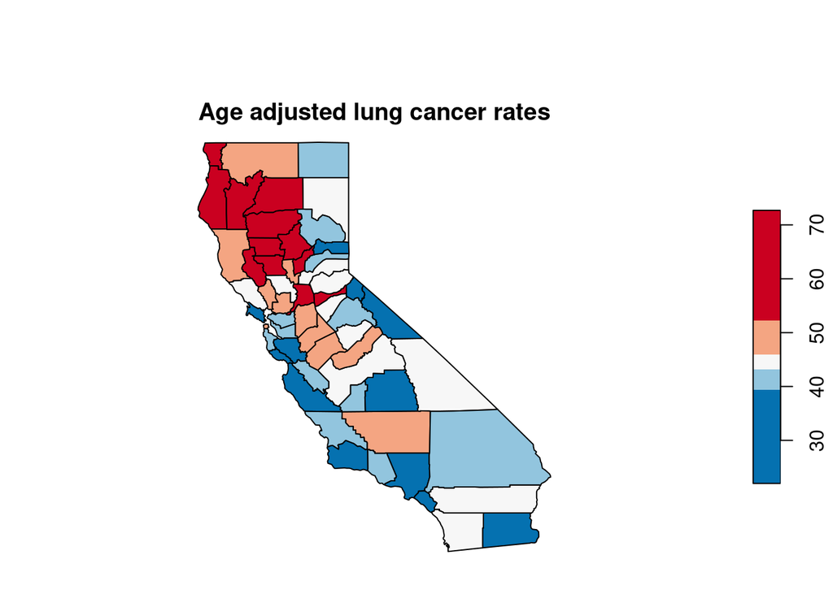

```r
yFitPosteriorMedians <- CI_yFit[,grep("50%", colnames(CI_yFit))]
caCountySF$ModelFitted <- yFitPosteriorMedians
caCountySF$ObsData <- Y
brksModelFitted = quantile(caCountySF$ModelFitted, c(0, 0.2, 0.4, 0.6, 0.8, 1))
brksObsData = quantile(caCountySF$ObsData, c(0, 0.2, 0.4, 0.6, 0.8, 1))

colorPalette = rev(brewer.pal(5,"RdBu"))

par(mfrow=c(1,2), oma = c(0,0,4,0) + 0.1, mar = c(0,0,1,0) + 0.1)

plot(caCountySF["ObsData"], pal = colorPalette, breaks = brksObsData, main = "Age adjusted lung cancer rates")
```

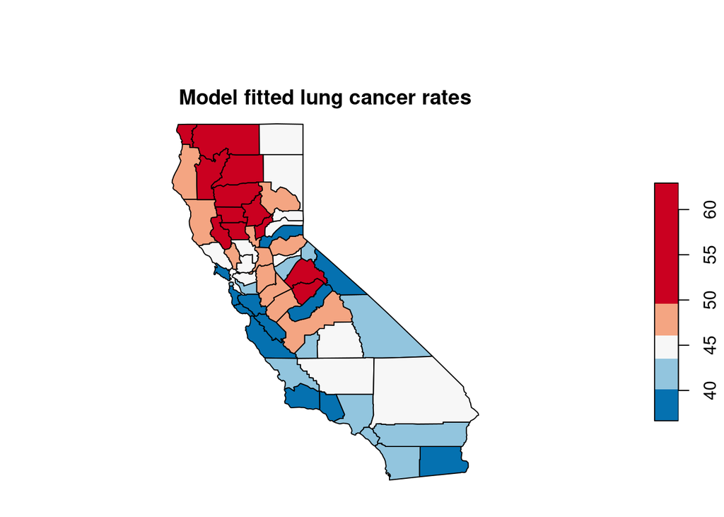

```r
plot(caCountySF["ModelFitted"], pal = colorPalette, breaks = brksModelFitted, main = "Model fitted lung cancer rates")
```